# 20-R-Graphics

南墙

2022.04.06

# 常用高级图形

## 条形图

从cancer.csv读入数据

```r
d.cancer <- readr::read_csv("D:\\Codefield\\R\\Statistical-Computing\\R Graphics\\cancer.csv")
```

用table()函数创建列联表

```r
res1 <- table(d.cancer[, "sex"])
print(res1)
```

```
##
##  F  M
## 13 21
```

画出条形图:

main选项增加标题，col选项使用不同的颜色，width选项与xlim选项配合调整条形宽度

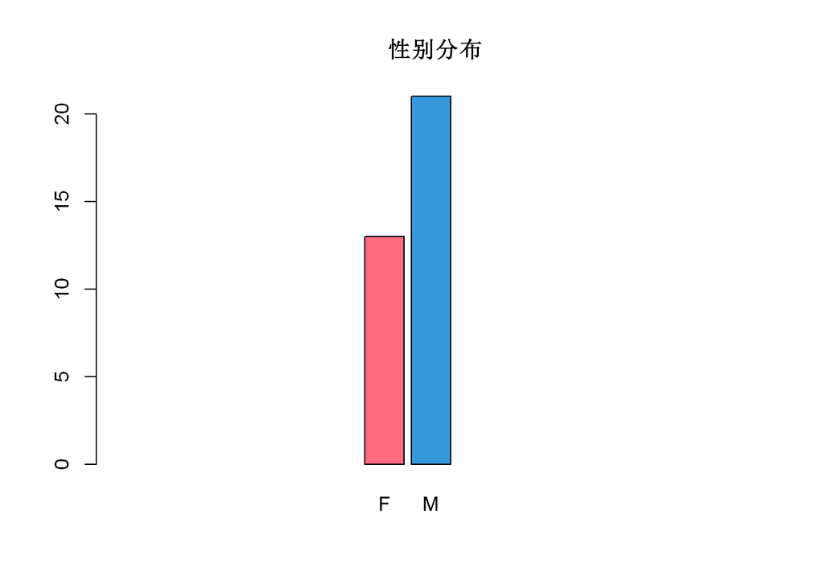

```r
barplot(res1, width = 0.5, xlim = c(-3, 5), main = "性别分布", col = c("#ff6b81",
    "#3498db"))
```

## 列联表

按性别与病理类型交叉分组后统计频数，结果称为列联表

```r
res2 <- with(d.cancer, table(sex, type))
print(res2)
```

```
##    type
## sex 鳞癌 腺癌
##   F    4    9
##   M   18    3
```

用分段条形图表现交叉分组频数，交叉频数表每列为一条

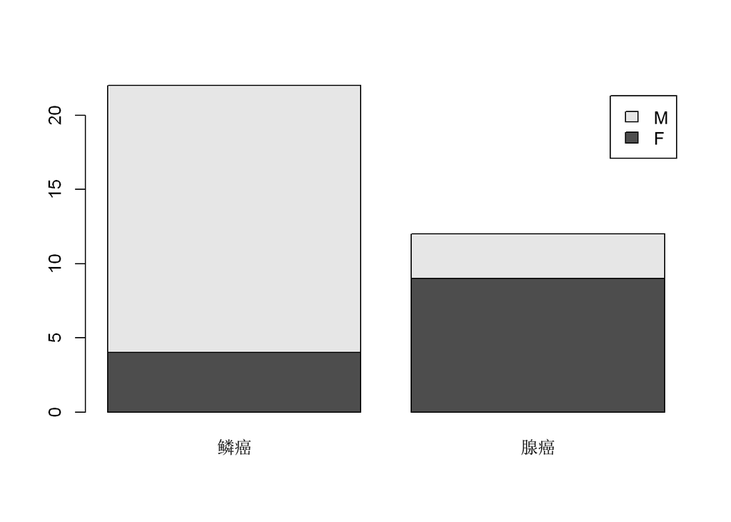

```r
barplot(res2, legend = TRUE)
```

用并排条形图表现交叉分组频数， 交叉频数表每列为一组

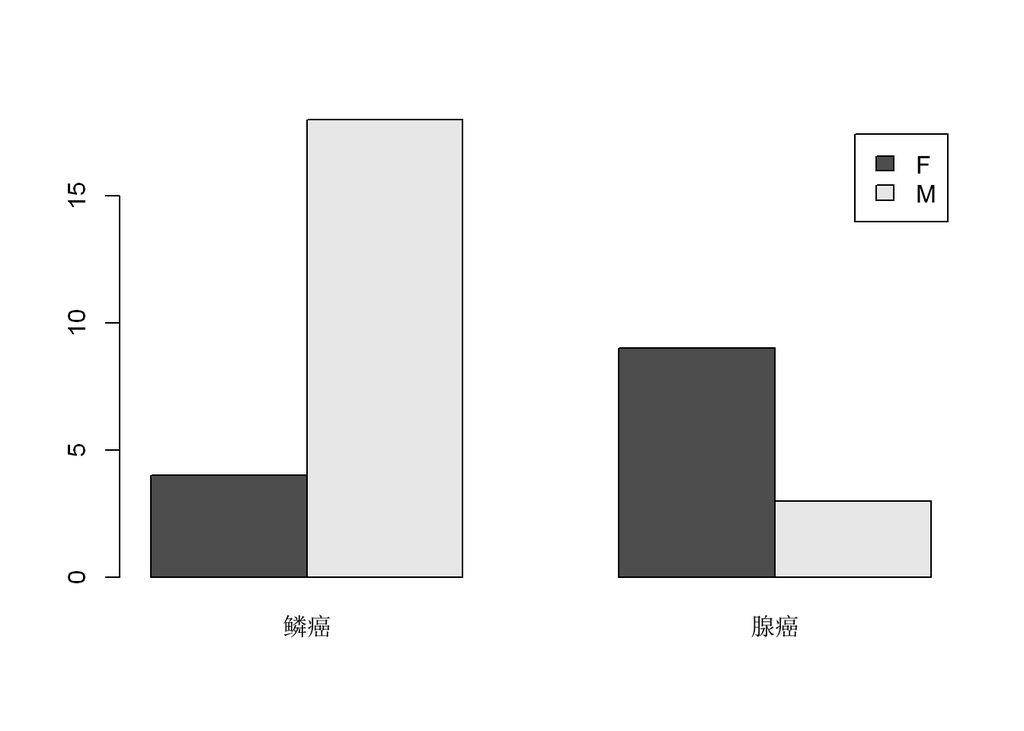

```r
barplot(res2, beside = TRUE, legend = TRUE)
```

## 直方图

函数`hist()`用来画直方图

可以用main=、xlab=、ylab=等选项指定标题和坐标轴， 可以用col=指定各个条形的颜色

```r
x <- rnorm(30, mean = 100, sd = 1)
print(round(x, 2))
```

```
##  [1] 100.49  99.25 101.98  98.76 100.04 101.33 100.53 100.77  99.95  99.56
## [11]  99.43  99.61  99.78  97.40 100.45 100.76 100.75  99.99  99.20  99.27
## [21]  99.91  99.01 101.11  97.85 100.18 101.62 101.57  99.81 100.59  98.85
```

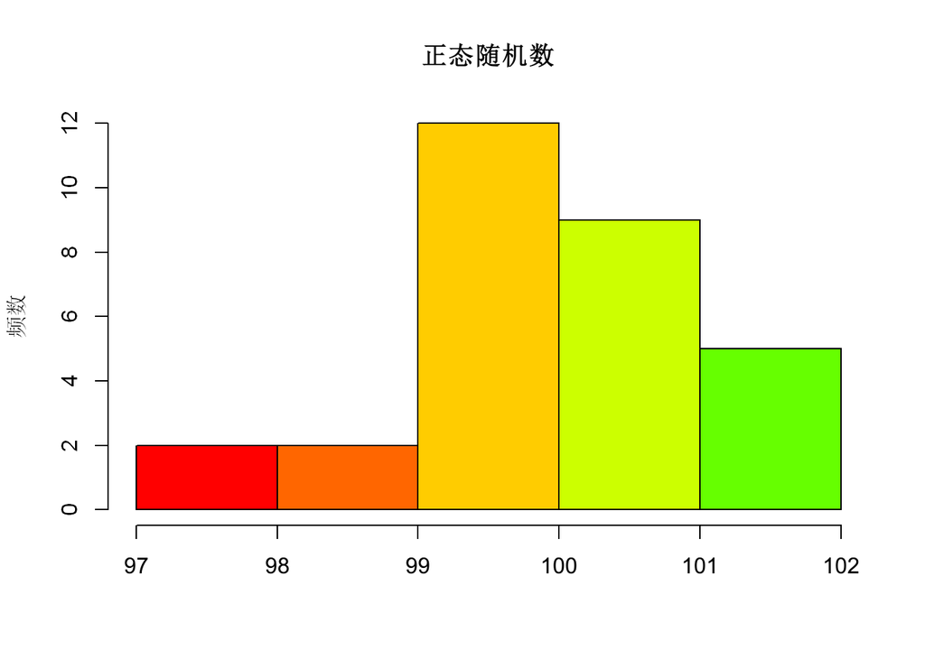

```r
hist(x, col = rainbow(15), main = "正态随机数", xlab = "", ylab = "频数")
```

## 密度估计图

函数`density()`估计核密度。下面的程序作直方图，并添加核密度曲线

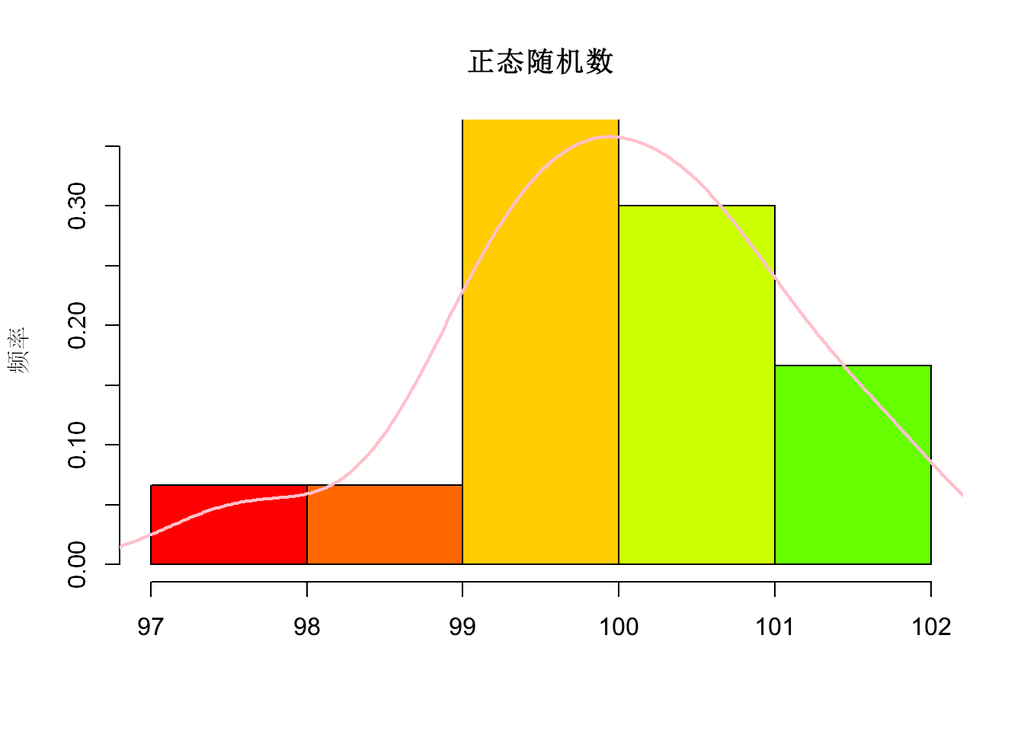

```r
tmp.dens <- density(x)
hist(x, freq = FALSE, ylim = c(0, max(tmp.dens$y)), col = rainbow(15), main = "正态随机数",
    xlab = "", ylab = "频率")
lines(tmp.dens, lwd = 2, col = "pink")
```

## 箱型图

箱型图的横线表示各个分位点

其中中间粗线是中位数， 盒子上下边缘是$\frac{1}{4}$和$\frac{3}{4}$分位数， 两条触须线延伸到取值区域的边缘。

盒形图可以很容易地比较两组或多组，如

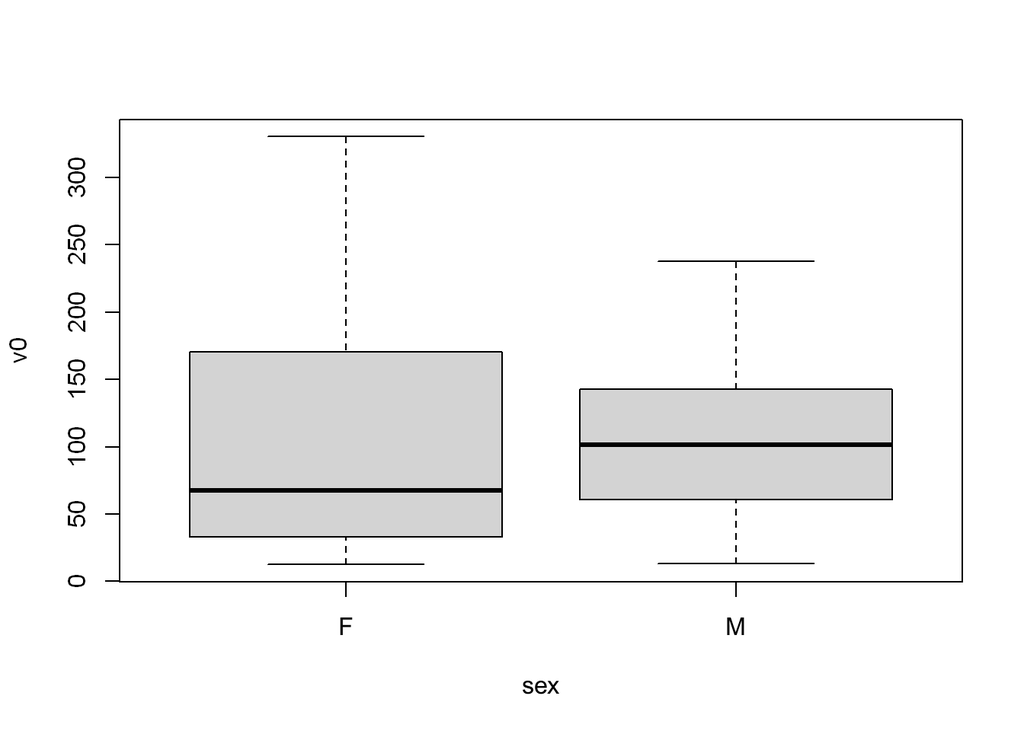

```r
with(d.cancer, boxplot(v0 ~ sex))
```

也可以画若干个变量的并排盒形图，如

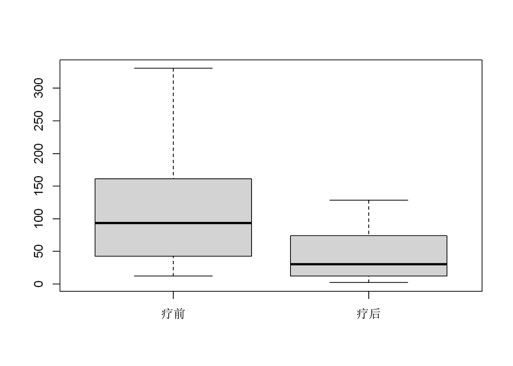

```r
with(d.cancer, boxplot(list(疗前 = v0, 疗后 = v1)))
```

## 正态QQ图

用`qqnorm`和`qqline`作正态QQ图。

当变量样本来自正态分布总体时，正态QQ图的散点近似在一条直线周围。

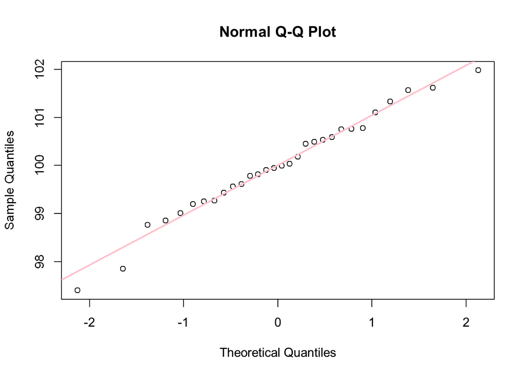

```r
qqnorm(x)
qqline(x, lwd = 2, col = "pink")
```

## 散点图

```r
d.class <- readr::read_csv("D:\\Codefield\\R\\Statistical-Computing\\R Graphics\\class.csv")
```

画出体重对身高的散点图

在`plot()`函数内用`main`参数增加标题， 用`xlab`参数指定横轴标注， 用`ylab`参数指定纵轴标注，如

用`pch`参数指定不同散点形状，用`col`参数指定颜色， 用`cex`参数指定大小，如：

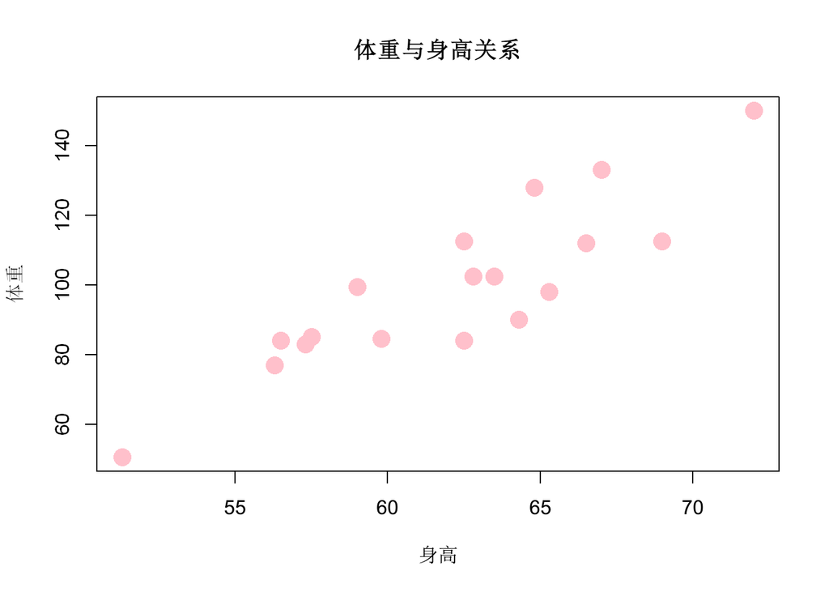

```r
with(d.class, plot(height, weight, main = "体重与身高关系", xlab = "身高", ylab = "体重",
    pch = 16, col = "pink", cex = 2))
```

用气泡大小表现年龄， 用颜色区分性别

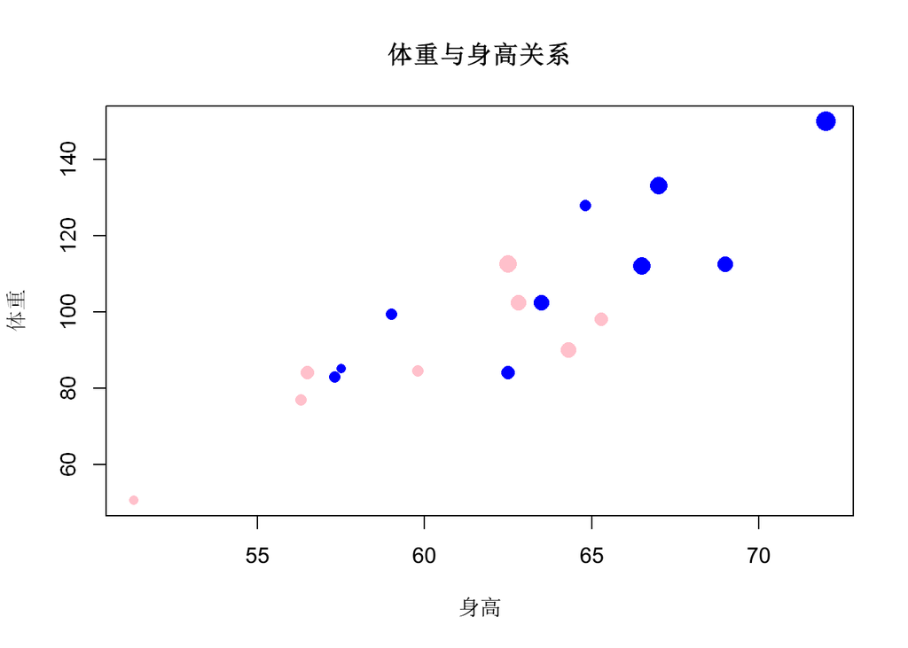

```r
with(d.class, plot(height, weight, main = "体重与身高关系", xlab = "身高", ylab = "体重",
    pch = 16, col = ifelse(sex == "M", "blue", "pink"), cex = 1 + (age - min(age))/(max(age) -
        min(age))))
```

`用`pairs()`函数可以做散点图矩阵

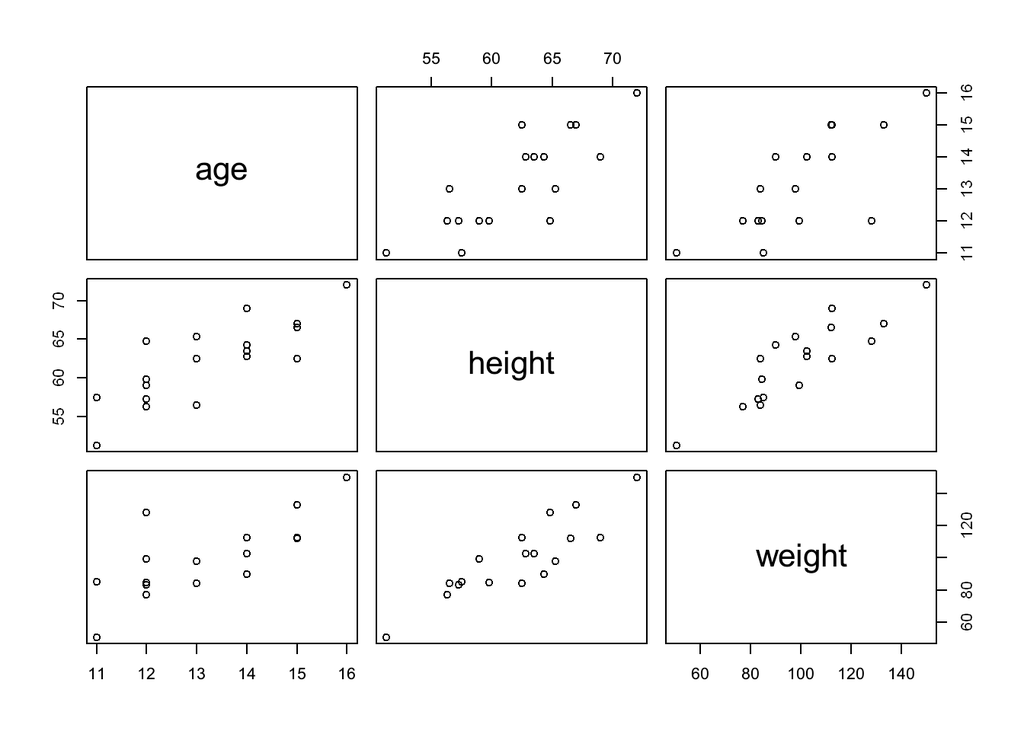

```r
pairs(d.class[, c("age", "height", "weight")])
```

## 曲线图

`curve()`函数接受一个函数，或者一个以x为变量的表达式，以及曲线的自变量的左、右端点，绘制函数或者表达式的曲线图

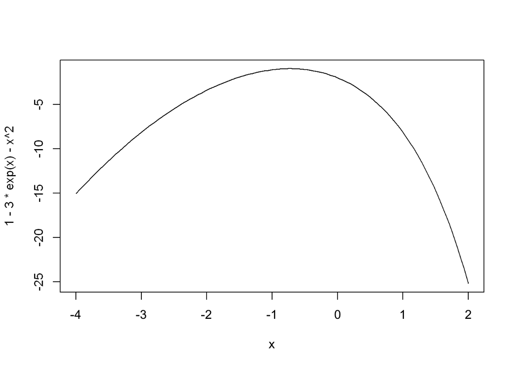

```r
curve(1 - 3 * exp(x) - x^2, -4, 2)
```

在`plot()`函数中使用 `type=’l’`参数可以作曲线图

除了仍可以用`main`, `xlab`, `ylab`, `col`等参数外，还可以用`lwd`指定线宽度，`lty`指定虚线，如

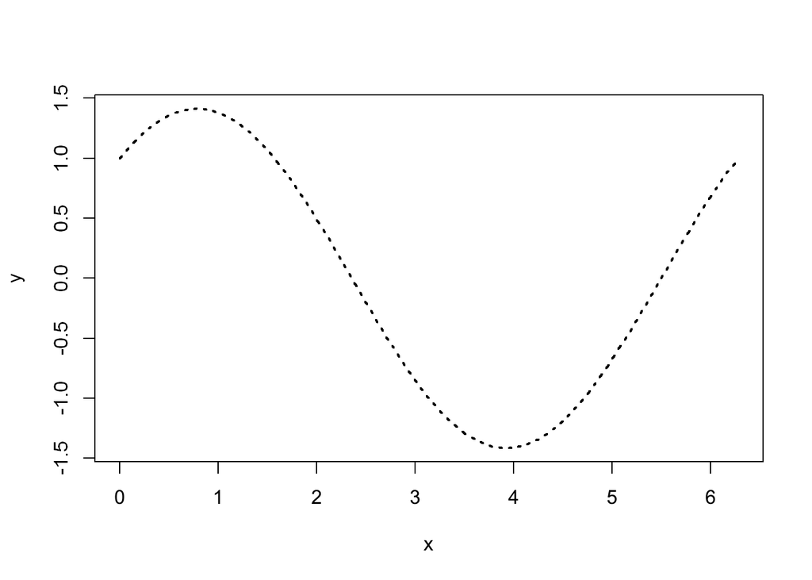

```r
x <- seq(0, 2 * pi, length = 200)
y <- cos(x) + sin(x)
plot(x, y, type = "l", lwd = 2, lty = 3)
```

多条曲线， 可以用`matplot()`函数。例如

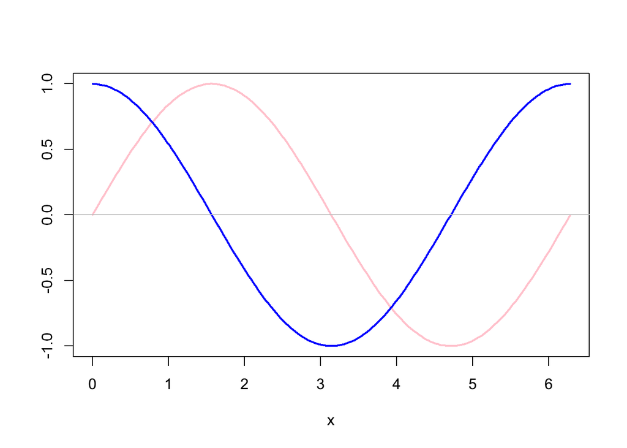

```r
x <- seq(0, 2 * pi, length = 200)
y1 <- sin(x)
y2 <- cos(x)
matplot(x, cbind(y1, y2), type = "l", lty = 1, lwd = 2, col = c("pink", "blue"),
    xlab = "x", ylab = "")
abline(h = 0, col = "gray")
```

## 三维图

用`persp`函数作三维曲面图, `contour`作等值线图， `image`作色块图。 坐标`x`和`y`构成一张平面网格， 数据`z`是包含`z`坐标的矩阵，每行对应一个横坐标， 每列对应一个纵坐标。

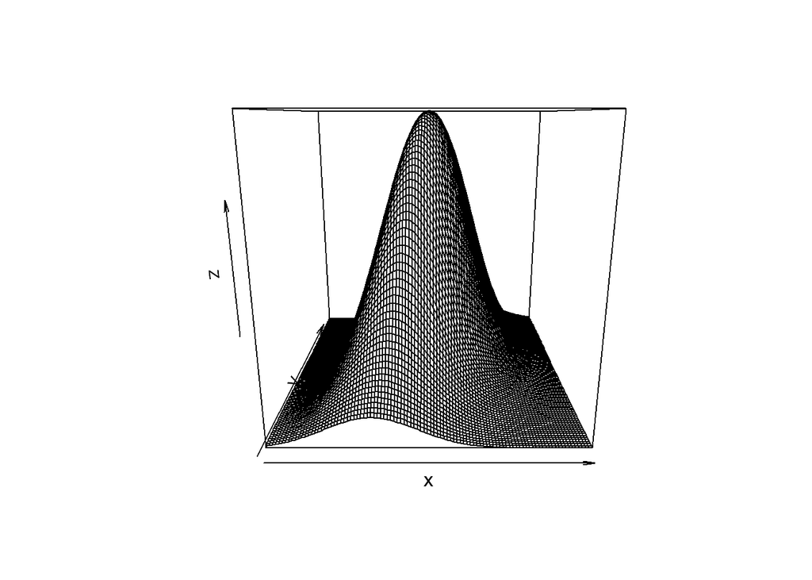

```r
x <- seq(-3, 3, length = 100)
y <- x
f <- function(x, y, ssq1 = 1, ssq2 = 2, rho = 0.5) {
    det1 <- ssq1 * ssq2 * (1 - rho^2)
    s1 <- sqrt(ssq1)
    s2 <- sqrt(ssq2)
    1/(2 * pi * sqrt(det1)) * exp(-0.5/det1 * (ssq2 * x^2 + ssq1 * y^2 - 2 * rho *
        s1 * s2 * x * y))
}
z <- outer(x, y, f)
persp(x, y, z)
```

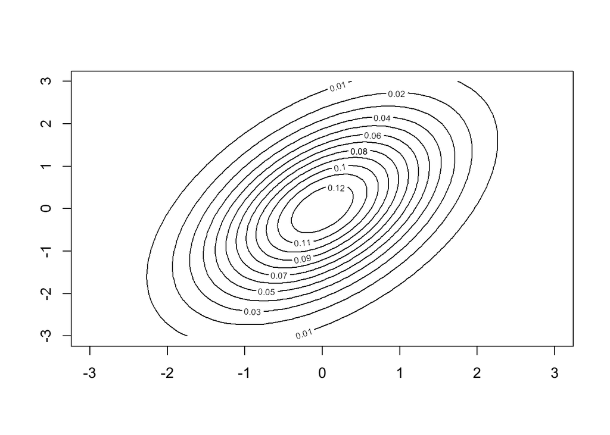

```r
contour(x, y, z)
```

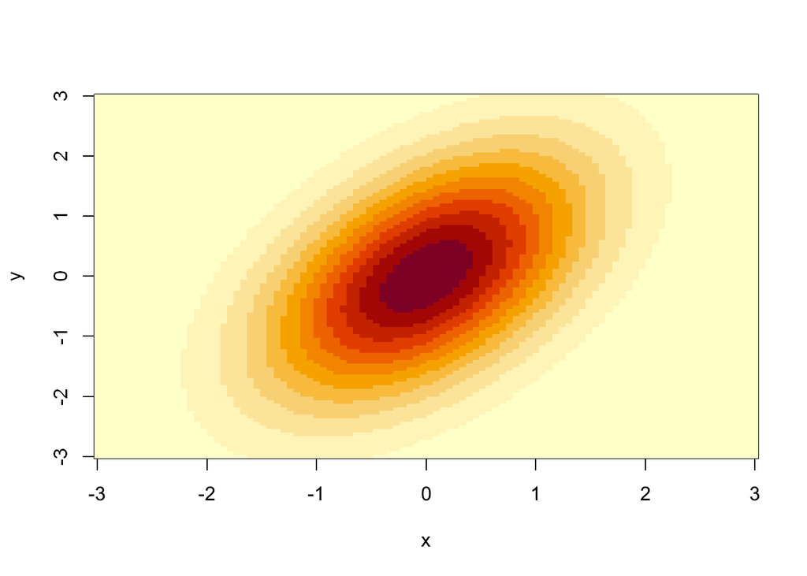

```r
image(x, y, z)
```

# ggplot作图

## 散点图

首先调用ggplot()函数， 指定数据集， 将身高映射到x轴， 将体重映射到y轴， 结果保存为一个R变量

```r
library("ggplot2")
p <- ggplot(data = d.class, mapping = aes(x = height, y = weight))
```

在如上指定了数据和映射后， 只要用`geom_xxx()`指定一个图形类型， 并与`ggplot()`的结果用加号连接就可以作图了

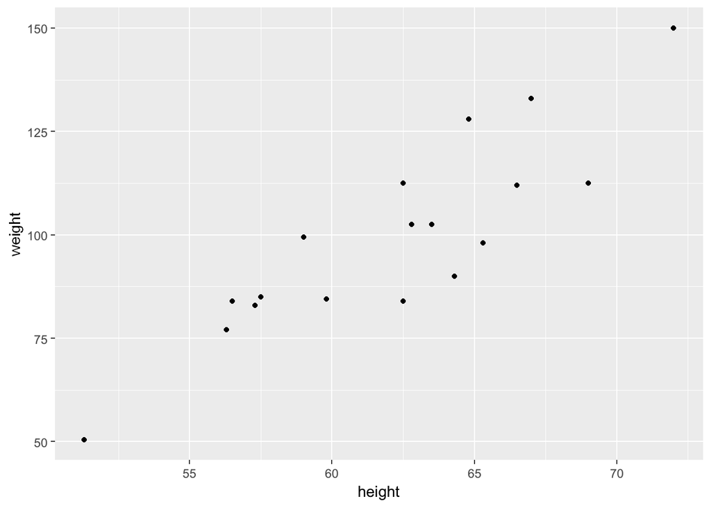

```r
p + geom_point()
```

用相同的映射做出拟合曲线图

`geom_smooth()`的默认设置调用了`gam()`函数来拟合曲线， 可以用`geom_smooth()`的参数选择不同的拟合方法， 如直线拟合

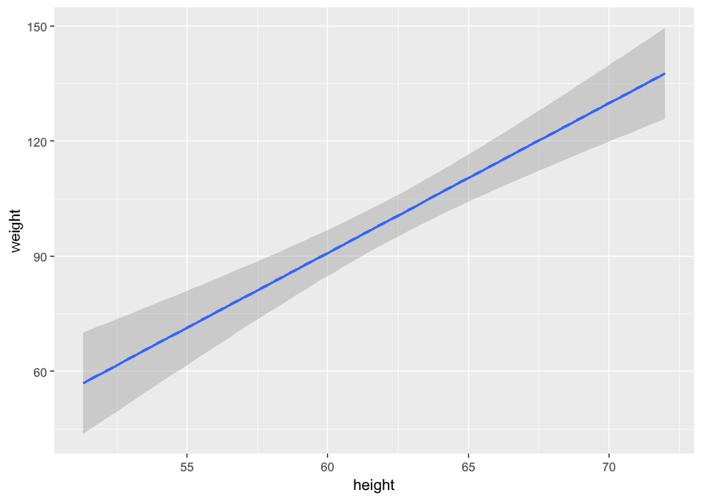

```r
p + geom_smooth(method = "lm")
```

用相同的映射做出散点图并叠加拟合曲线图

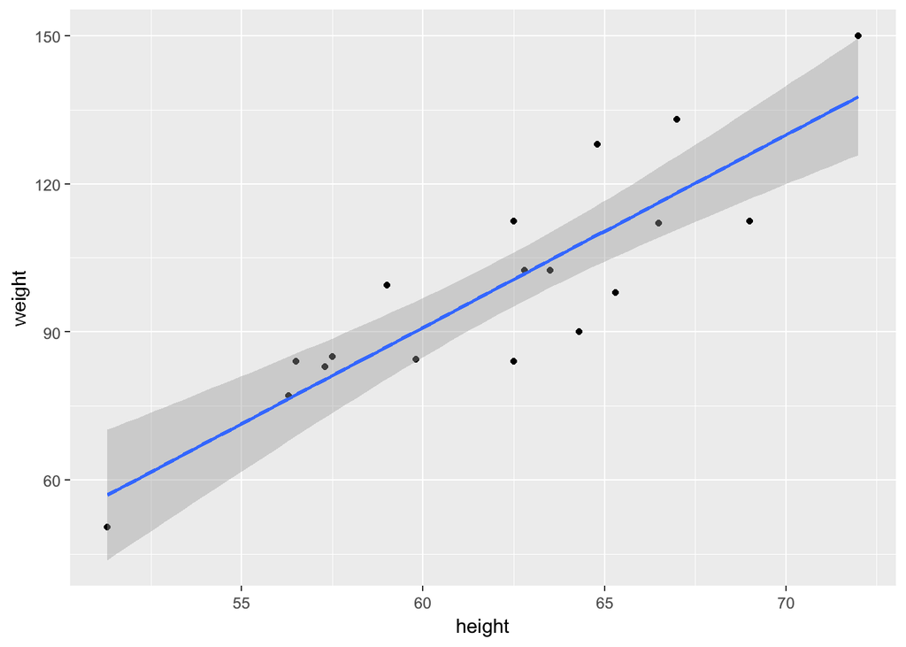

```r
p + geom_point() + geom_smooth(method = "lm")
```

# R Graphic Gallary中的图形

## 词云图

```r
library(wordcloud2)
wordcloud2(data = demoFreqC, size = 2, fontFamily = "Source Han Serif", color = "random-light",
    backgroundColor = "grey")
```

[interactive chart not shown]